# Offshore Ornithology - Firth of Forth case: Desk-Based Baseline

A learning exercise, not a real assessment

Author

Thayusky da Penha Correa

Published

November 12, 2026

**NoteA learning exercise**

I built this document to learn R Shiny and Quarto after a workshop at the MASTS Annual Science Meeting 2026. It is practice, not a real environmental assessment. See About this exercise at the end for how to send corrections.

## 1 Introduction

This report describes the seabirds recorded in the Firth of Forth from historical boat surveys. It is the first step of an ornithology assessment: establishing which species use the area, where, and when.

## 2 Data and methods

### 2.1 Data used

| Data | Source | Details |
| --- | --- | --- |
| Seabird sightings | JNCC Seabirds at Sea (ESAS), accessed through GBIF | Dataset “JNCC seabird distribution and abundance data (all trips) from ESAS database”, GBIF dataset key `93c8cc03-30cf-474e-8173-dbe5a22a5d28`. Boat surveys, 1979 to 2000. Licence CC BY-NC 4.0. |
| Study area | Bounding box set in the download script | 55.9 to 56.4 N, 3.4 to 1.8 W (Firth of Forth and outer approaches). |
| Key species lookup | Compiled by the author as a draft | Seven species with their main risk from offshore wind and their link to the Forth protected colonies. Not part of the JNCC data. |
| Background map | OpenStreetMap, through the `leaflet` package | Used for display only. |

The sightings were downloaded on 12 November 2026 with an R script that calls the GBIF API and keeps date, position, species and count.

### 2.2 Sample analysed

The analysis uses **12,515 sightings** of **50 species** recorded between **1985** and **1998**. This is part of the roughly 30,000 records available for the area, because the download stopped early.

### 2.3 Methods

Key species were selected for their link to the Forth protected seabird colonies and their sensitivity to offshore wind farms. They are joined to the sightings by Latin name. Counts are summed by species, by month, and by season.

Software: R version 4.6.2 (2026-10-29 ucrt), with the packages dplyr, readr, ggplot2, leaflet and knitr, rendered with Quarto.

## 3 Baseline

### 3.1 Key species

The most recorded key species is **Guillemot**, with 9,004 birds counted.

| Species | Main risk | Forth SPA species | Sightings | Birds |
| --- | --- | --- | --- | --- |
| Guillemot | Displacement | Yes | 4,568 | 9,004 |
| Herring gull | Collision | Yes | 770 | 5,733 |
| Gannet | Collision | Yes (Bass Rock) | 1,310 | 3,961 |
| Puffin | Displacement | Yes (Isle of May) | 2,118 | 3,656 |
| Kittiwake | Collision | Yes | 894 | 2,011 |
| Razorbill | Displacement | Yes | 644 | 978 |
| Fulmar | Low | Yes | 438 | 566 |

### 3.2 Distribution

Each dot is one sighting of a key species, coloured by its main risk.

[interactive chart not shown]

### 3.3 Seasonality

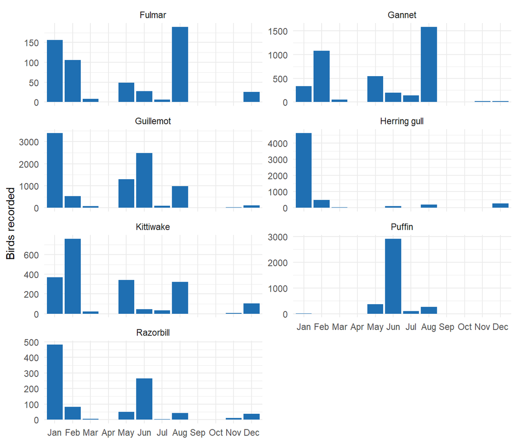

### 3.4 Breeding and non-breeding seasons

Breeding season is taken as April to August for all species, which is a simplification.

| Species | Breeding (Apr-Aug) | Non-breeding (Sep-Mar) |
| --- | --- | --- |
| Fulmar | 271 | 295 |
| Gannet | 2,465 | 1,496 |
| Guillemot | 4,867 | 4,137 |
| Herring gull | 325 | 5,408 |
| Kittiwake | 745 | 1,266 |
| Puffin | 3,639 | 17 |
| Razorbill | 360 | 618 |

## 4 Limitations

- Counts are raw sightings, not densities. They reflect where and when boats surveyed.
- The data end around 2000 and do not describe present-day conditions.
- Only part of the available dataset was downloaded for this example.
- A real assessment needs recent site-specific surveys, typically two years of monthly data.

## 5 Next steps in a full EIA

1. Commission current surveys of the site and a surrounding buffer.
2. Estimate densities and populations for each key species.
3. Assess collision and displacement, alone and with other projects.
4. Propose mitigation and monitoring.

## 6 Discussion: data sources and workflow

### 6.1 Where the data come from

The sightings come from the **JNCC Seabirds at Sea** database, part of the European Seabirds at Sea (ESAS) collaboration. Trained observers on boats counted seabirds along survey routes using the standard ESAS method, recording species, number, date and position. The public dataset covers 1979 to 2000 and holds about 1.1 million records across north-west European waters.

The data were accessed through **GBIF** (Global Biodiversity Information Facility). Only records inside a box around the Firth of Forth were requested. The GBIF copy is licensed CC BY-NC 4.0 (non-commercial use, with attribution).

The key species table is **not** part of the JNCC data. It was compiled separately as a draft and must be checked against official sources (NatureScot SiteLink citations for the Forth protected areas, and the UK Birds of Conservation Concern list) before any real use.

### 6.2 How the workflow was built

```
flowchart LR
  A[GBIF: JNCC Seabirds at Sea] --> B[R script: download and tidy]
  B --> C[data/forth_birds.csv]
  K[Key species lookup] --> D
  C --> D[Shared R code: filter, join, summarise]
  D --> E[Shiny app: explore]
  D --> F[Quarto report: document]
```

1. **Download and tidy (R).** A script requested the records from the GBIF API, kept date, position, species and count, added year and month, and saved one CSV file.
2. **Key species lookup.** A small table links each key species to its main risk from offshore wind (collision or displacement) and to the Forth protected colonies. It is joined to the sightings by Latin name.
3. **Explore (Shiny).** An interactive app filters the data by species, years and months, and shows a map, a seasonality chart and the key species table.
4. **Report (Quarto).** This document runs the same code from top to bottom and writes the results into text, tables and figures. Changing the parameters at the top and rendering again produces an updated report.

### 6.3 What this approach offers

- **Reproducible:** every number in this report is calculated from the data when the document is rendered, so text and results cannot drift apart.
- **Reusable:** the same template works for another area, period or dataset.
- **Transparent:** the code, the data source and the limitations are all stated.

### 6.4 What it does not replace

This is a desk-based exercise. It does not replace current site-specific surveys, density estimation, or collision and displacement modelling, which a real assessment requires.

## 7 About this exercise

This document is a learning exercise. I started it from zero during and after the “Marine Data Transformation in Industry” workshop, run by the Haskoning team at the MASTS Annual Science Meeting 2026, to practise R Shiny and Quarto with real data. I had help from Claude, an AI assistant, to write and debug the code.

**It is not a real environmental assessment**, and nothing here should be used to draw conclusions about seabirds in the Firth of Forth or about any development.

I plan to keep updating it as a portfolio piece and as a practical way to keep learning. Things I would like to add next:

- the full set of records for the area;
- the conservation status of each species;
- a proposed site with a buffer, to count birds inside it;
- official boundaries of the protected areas.

Corrections, suggestions and help to build on it are very welcome. You can find the code and get in touch through my GitHub: https://github.com/thayusky.

*Last updated: 12 November 2026.*